# Assignment 3 IBM Employee Attrition Prediction

Veronika Varaksina s4646146

Diem Nga N Hoang s4644368

2021-11-30

# Business case

## Explore & understand dataset - IBM employee attrition

```r
data <- read.csv('IBM_data.csv')
```

Data cleaning

In order for us to visualize and model data, data frame has to have clean names, be consistent, not include any NA values and not redundant. The data quality was improved by using clean_names function, that standardizes column names and removing columns that do not hold any value for this research. That includes:

- employee count, that corresponds to index of the data frame;
- over18, all employees in this data frame are over 18 years old, the data does not hold any necessary information;
- standard hours are equal to 80 hour for every employee;
- performance rating ranges only from 3 to 4 and is not representative, since every one in the company seems to perform on a similar level.

```r
#cleaning the names
data <- data %>%
  clean_names() %>%
  select(-employee_count, -over18, -standard_hours, -performance_rating)

data_attrition_yes <- data %>%
  filter(attrition == "Yes")

data_attrition_no <- data %>%
  filter(attrition == "No")
```

```r
skim(data)
```

Data summary

| Name | data |
| --- | --- |
| Number of rows | 1470 |
| Number of columns | 31 |
| _______________________ |  |
| Column type frequency: |  |
| character | 8 |
| numeric | 23 |
| ________________________ |  |
| Group variables | None |

**Variable type: character**

| skim_variable | n_missing | complete_rate | min | max | empty | n_unique | whitespace |
| --- | --- | --- | --- | --- | --- | --- | --- |
| attrition | 0 | 1 | 2 | 3 | 0 | 2 | 0 |
| business_travel | 0 | 1 | 10 | 17 | 0 | 3 | 0 |
| department | 0 | 1 | 5 | 22 | 0 | 3 | 0 |
| education_field | 0 | 1 | 5 | 16 | 0 | 6 | 0 |
| gender | 0 | 1 | 4 | 6 | 0 | 2 | 0 |
| job_role | 0 | 1 | 7 | 25 | 0 | 9 | 0 |
| marital_status | 0 | 1 | 6 | 8 | 0 | 3 | 0 |
| over_time | 0 | 1 | 2 | 3 | 0 | 2 | 0 |

**Variable type: numeric**

| skim_variable | n_missing | complete_rate | mean | sd | p0 | p25 | p50 | p75 | p100 | hist |
| --- | --- | --- | --- | --- | --- | --- | --- | --- | --- | --- |
| age | 0 | 1 | 36.92 | 9.14 | 18 | 30.00 | 36.0 | 43.00 | 60 | ▂▇▇▃▂ |
| daily_rate | 0 | 1 | 802.49 | 403.51 | 102 | 465.00 | 802.0 | 1157.00 | 1499 | ▇▇▇▇▇ |
| distance_from_home | 0 | 1 | 9.19 | 8.11 | 1 | 2.00 | 7.0 | 14.00 | 29 | ▇▅▂▂▂ |
| education | 0 | 1 | 2.91 | 1.02 | 1 | 2.00 | 3.0 | 4.00 | 5 | ▂▃▇▆▁ |
| employee_number | 0 | 1 | 1024.87 | 602.02 | 1 | 491.25 | 1020.5 | 1555.75 | 2068 | ▇▇▇▇▇ |
| environment_satisfaction | 0 | 1 | 2.72 | 1.09 | 1 | 2.00 | 3.0 | 4.00 | 4 | ▅▅▁▇▇ |
| hourly_rate | 0 | 1 | 65.89 | 20.33 | 30 | 48.00 | 66.0 | 83.75 | 100 | ▇▇▇▇▇ |
| job_involvement | 0 | 1 | 2.73 | 0.71 | 1 | 2.00 | 3.0 | 3.00 | 4 | ▁▃▁▇▁ |
| job_level | 0 | 1 | 2.06 | 1.11 | 1 | 1.00 | 2.0 | 3.00 | 5 | ▇▇▃▂▁ |
| job_satisfaction | 0 | 1 | 2.73 | 1.10 | 1 | 2.00 | 3.0 | 4.00 | 4 | ▅▅▁▇▇ |
| monthly_income | 0 | 1 | 6502.93 | 4707.96 | 1009 | 2911.00 | 4919.0 | 8379.00 | 19999 | ▇▅▂▁▂ |
| monthly_rate | 0 | 1 | 14313.10 | 7117.79 | 2094 | 8047.00 | 14235.5 | 20461.50 | 26999 | ▇▇▇▇▇ |
| num_companies_worked | 0 | 1 | 2.69 | 2.50 | 0 | 1.00 | 2.0 | 4.00 | 9 | ▇▃▂▂▁ |
| percent_salary_hike | 0 | 1 | 15.21 | 3.66 | 11 | 12.00 | 14.0 | 18.00 | 25 | ▇▅▃▂▁ |
| relationship_satisfaction | 0 | 1 | 2.71 | 1.08 | 1 | 2.00 | 3.0 | 4.00 | 4 | ▅▅▁▇▇ |
| stock_option_level | 0 | 1 | 0.79 | 0.85 | 0 | 0.00 | 1.0 | 1.00 | 3 | ▇▇▁▂▁ |
| total_working_years | 0 | 1 | 11.28 | 7.78 | 0 | 6.00 | 10.0 | 15.00 | 40 | ▇▇▂▁▁ |
| training_times_last_year | 0 | 1 | 2.80 | 1.29 | 0 | 2.00 | 3.0 | 3.00 | 6 | ▂▇▇▂▃ |
| work_life_balance | 0 | 1 | 2.76 | 0.71 | 1 | 2.00 | 3.0 | 3.00 | 4 | ▁▃▁▇▂ |
| years_at_company | 0 | 1 | 7.01 | 6.13 | 0 | 3.00 | 5.0 | 9.00 | 40 | ▇▂▁▁▁ |
| years_in_current_role | 0 | 1 | 4.23 | 3.62 | 0 | 2.00 | 3.0 | 7.00 | 18 | ▇▃▂▁▁ |
| years_since_last_promotion | 0 | 1 | 2.19 | 3.22 | 0 | 0.00 | 1.0 | 3.00 | 15 | ▇▁▁▁▁ |
| years_with_curr_manager | 0 | 1 | 4.12 | 3.57 | 0 | 2.00 | 3.0 | 7.00 | 17 | ▇▂▅▁▁ |

Skimming through our dataset, we have these variables type:

- **Numeric variables**:
  - Related to personal information: age, distance_from_home, employee_number (id variable)
  - Related to income: hourly_rate, daily_rate, monthly_rate, monthly_income, percent_salary_hike
  - Related to time in company: years_at_company, years_in_current_role, years_since_last_promotion, years_with_curr_manager, total_working_years
  - other: num_companies_worked, standard_hours(to delete), training_times_last_year, employee_count (to delete)
- **Categorical variables**:
  - **Binary variables**: attrition(target variable), gender, over18 (to delete), over_time
  - **Nominal variables**: department, education_field, job_role, marital_status
  - **Ordinal variables**:
    - Ordinal regarding satisfaction and performance : environment_satisfaction, job_satisfaction, relationship_satisfaction, work_life_balance,job_involvement,performance_rating
    - Other ordinal: business_travel, education, job_level, stock_option_level

Explanation for some variables:

Question of topic: **What is attrition**

Attrition: It is basically the turnover rate of employees inside an organization.

Attrition in our data set is recorded as ‘Yes’/‘No’. ‘Yes’ is when the employees leave the company and ‘No’ is otherwise.

This can happen for many reasons:

- Employees looking for better opportunities.
- A negative working environment.
- Bad management
- Sickness of an employee (or even death)
- Excessive working hours

Turnover has negative consequence for a company, since company’s resources have to be spend on finding employees replacements. And depending on the job role, the costs associated with hiring can be very high, especially for more complicated executive position, as the level of uncertainty is attached to criteria of choosing any particular candidate. Hiring costs are noticeably lower for job positions where job scope defines easier and criteria for candidates is very clear.

IBM is a technology corporation, therefore, there are plethora of job position that require a very specific set of skills, level of education and work experience, where the costs of losing an employee is high. It is in company’s interest to decrease hiring costs.

Researching and modelling attrition can be one of the ways to reduce IBM turnover rate. Not only will we be able to understand company’s “problem” zones when it comes to turnover, but we also will able to predict employees attrition. That information can help HR department make data driven decisions and build new strategy for reducing turnover rate, helping company retain competent employees and reduce HR costs.

**Question: What affects employee attrition?**

Sub question 1: How personal profile affects the attrition?

Sub question 2: How work and work travel affects the attrition?

Sub question 3: How environment, job satisfaction and involvement affects the attrition?

Sub question 4: Clustering the employees based on attrition. What kind of employees burn out?

# Exploratory Data Analysis & Visualisation

## How personal profile affects the attrition?

Amongst the variables in the data set, we classify age, education, marital status, number of companies worked, and relationship satisfaction as employees’ personal profiles.

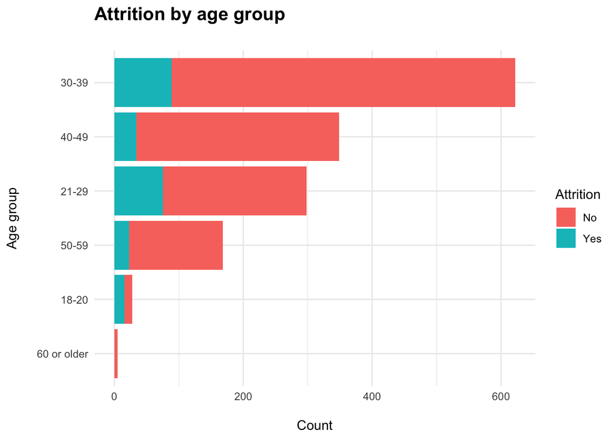

```r
data %>% mutate(age_group = case_when(18 <= age & age <= 20 ~ "18-20",
                                      21 <= age & age <= 29 ~ "21-29",
                                      30 <= age & age <= 39 ~ "30-39",
                                      40 <= age & age <= 49 ~ "40-49",
                                      50 <= age & age <= 59 ~ "50-59",
                                      60 <= age ~ "60 or older"
                                      ))  %>% count(attrition, age_group, sort = TRUE) %>%
  group_by(attrition) %>%
  mutate(age_group = fct_reorder(age_group, n)) %>%
  ggplot(aes(n, age_group, fill=attrition)) +
  geom_col() +
  labs(x = "\nCount",
       y = "Age group\n",
       title = "Attrition by age group\n")+
  scale_fill_discrete(name="Attrition") +
  theme(plot.title = element_text(size=15, face="bold"))
```

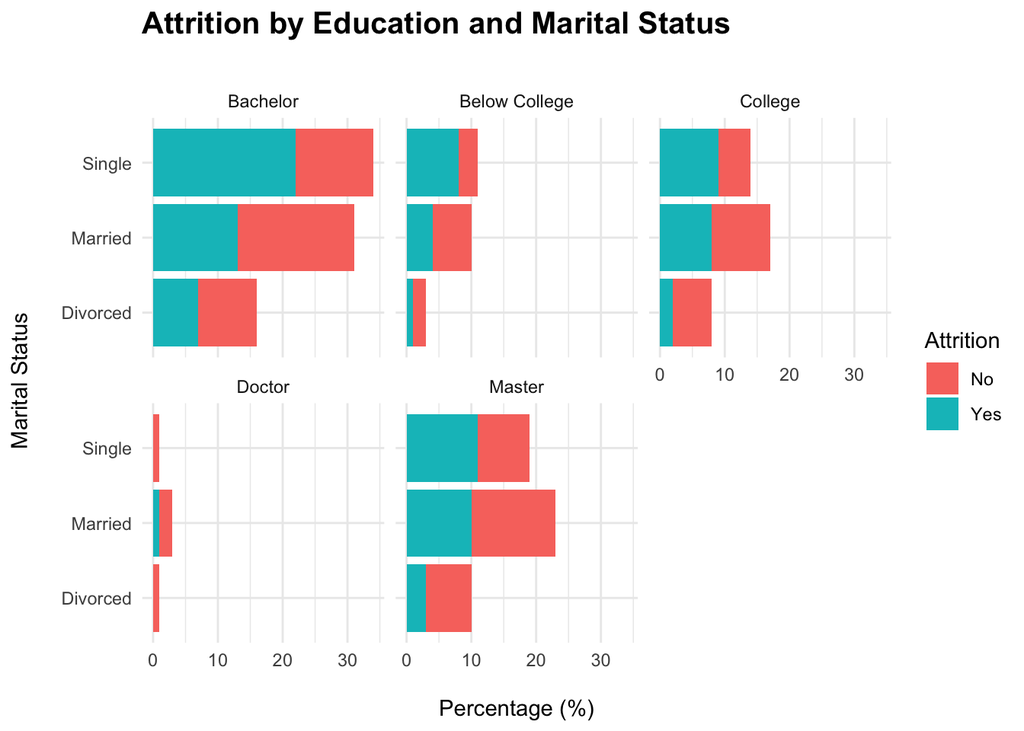

```r
data %>% mutate(education=case_when(education == 1 ~ 'Below College',
                                                    education == 2 ~ 'College',
                                                    education == 3 ~ 'Bachelor',
                                                    education == 4 ~ 'Master',
                                                    education == 5 ~ 'Doctor')) %>%
  count(attrition, marital_status, education, sort = TRUE) %>%
  group_by(attrition) %>%
  mutate(pct=round(prop.table(n),2) * 100) %>%
  ggplot(aes(x= pct, y=marital_status, fill = attrition))+
  geom_col()+
  facet_wrap(~ education)+
  labs(x="\nPercentage (%)",y=" Marital Status \n",
        title = "Attrition by Education and Marital Status \n")+
  scale_fill_discrete(name = "Attrition")+
  theme(plot.title = element_text(size=15, face="bold"))
```

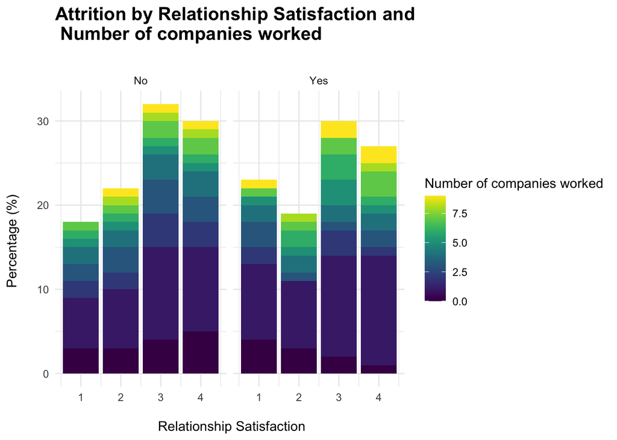

```r
data %>% count(attrition, num_companies_worked, relationship_satisfaction) %>%
  group_by(attrition) %>%
  mutate(pct=round(prop.table(n),2) * 100) %>%
  ggplot(aes(x=relationship_satisfaction, y=pct, fill=num_companies_worked))+
  geom_col()+
  facet_grid(~attrition)+
  labs(x="\n Relationship Satisfaction",y="Percentage (%) \n",
        title = "Attrition by Relationship Satisfaction and \n Number of companies worked \n")+
  scale_fill_viridis(option = "D", name = "Number of companies worked")+
  theme(plot.title = element_text(size=15, face="bold"))
```

## How work and work travel affects the attrition?

Among the variables in the dataset, we classify business travel, distance from home, job role, overtime, and work life balance as employees’ work travels.

- **Business travel**

In travel frequent category, almost 30% of people who decided to quit traveled frequently, in comparison to only 17% of those who stayed travel frequently. So the percentage of people who committed to quit and those who did not, almost doubles in frequent travelers. That leads to a conclusion that frequency of business travel does affect the attrition.

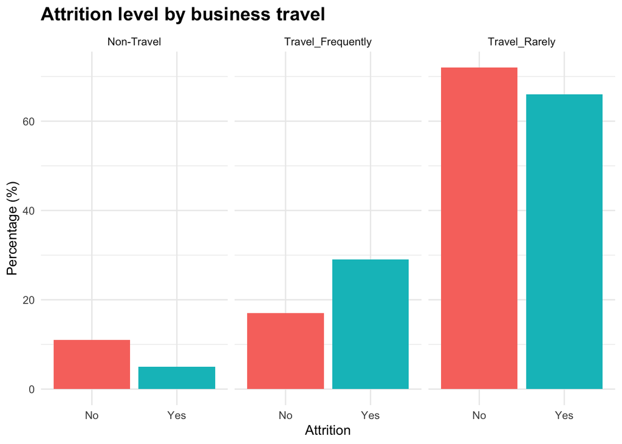

```r
data %>% count(attrition, business_travel) %>% group_by(attrition) %>%
  mutate(pct=round(prop.table(n),2) * 100) %>%
  ggplot(aes(x=attrition, y=pct,  fill=attrition)) +
  geom_bar(stat='identity') +
  facet_wrap(~business_travel)+
  labs(x="Attrition", y="Percentage (%)", title = "Attrition level by business travel")  +
  theme(legend.position="none", plot.title = element_text(size=15, face="bold"))
```

- **Work life balance vs distance from home**

This box plot showcases the distribution of distance from work to home by work life balance, where 1 is the worst work life balance and 4 is the best. We can see that people who decided to quit, if they rate their work life balance lower than 4, they also usually live further away from work. The distance from home is more evenly distributed in people who stayed, the box plot with positive attrition is less homogeneous. While people who are very satisfied with work-life balance live the same distance from work, as the ones who dint quit, majority of people who rate their work-life balance lower than 4 tend to live further away from work. That leads to a conclusion that distance from home does affect the work life balance and attrition, as those who live further from their offices, spend more time on daily travels.

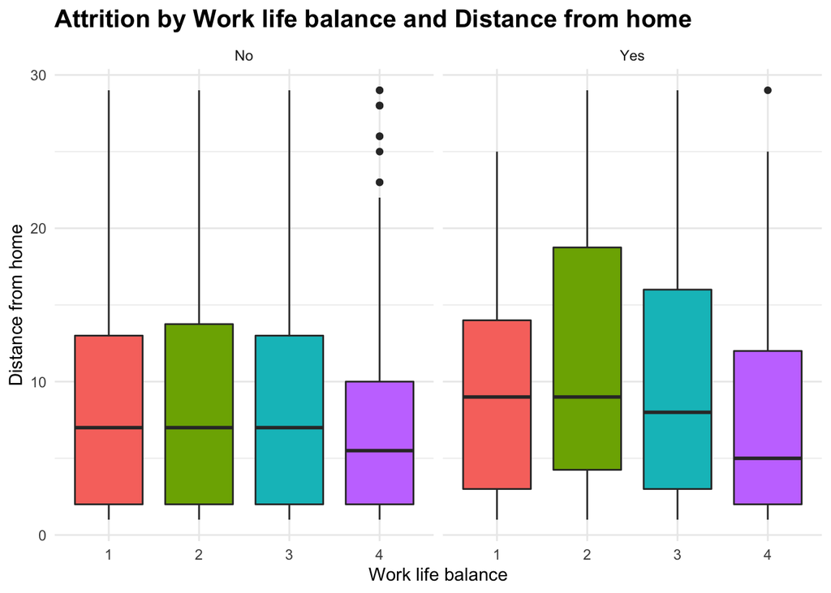

```r
data %>%
  mutate(work_life_balance = as.factor(work_life_balance)) %>%
  ggplot(aes(distance_from_home, work_life_balance, fill = work_life_balance)) +
  geom_boxplot() +
  coord_flip() +
  facet_wrap(~attrition) +
  labs(x="Distance from home", y="Work life balance", title = "Attrition by Work life balance and Distance from home") +
  theme(legend.position="none", plot.title = element_text(size=15, face="bold"))
```

- **Distance from home**

The average distance from work to home for IBM employee is 7 kilometers. And according to this plot among people who retired or left the company, 60% do live further.

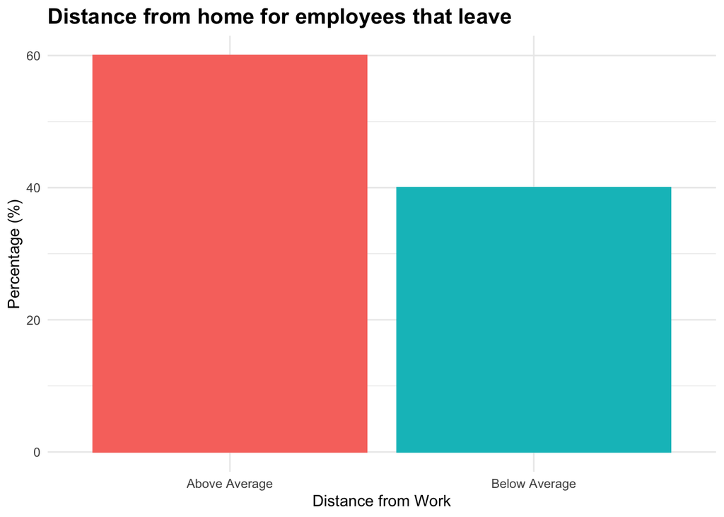

```r
# Average distance of employees that didn't quit.
med_distance <- data_attrition_no %>% select(distance_from_home) %>% summarize(med.dist=round(median(distance_from_home), 2))

data_attrition_yes$Median_Distance <- ifelse(data_attrition_yes$distance_from_home < 7, "Below Average", "Above Average")

data_attrition_yes %>% select(Median_Distance) %>% group_by(Median_Distance) %>%
  summarize(count=n()) %>% mutate(pct=round(prop.table(count),2) * 100) %>%
  ggplot(aes(x=Median_Distance, y=pct, color=Median_Distance, fill=Median_Distance)) +
  geom_bar(stat="identity") +
  labs(x="Distance from Work", y="Percentage (%)", title="Distance from home for employees that leave") +
  theme(legend.position="none", plot.title = element_text(size=15, face="bold"))
```

- **Job Role and Department**

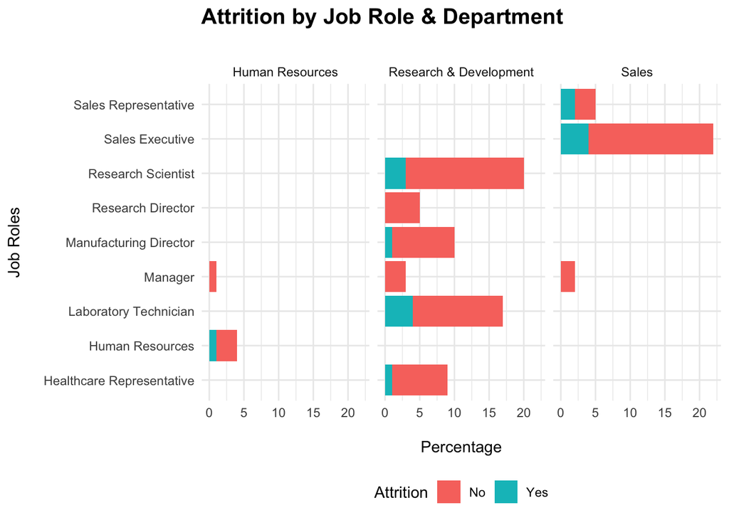

```r
data %>%
  group_by(job_role, attrition, department) %>%
  count() %>%
  mutate(n = round(n/1470*100)) %>%
  ggplot(aes(x=job_role, y = n, fill=attrition)) +
  geom_bar(stat="identity") +
  coord_flip()+
  facet_grid(~department)+
  labs(title="Attrition by Job Role & Department \n",x="Job Roles\n", y="\nPercentage")+
  scale_fill_discrete(name = "Attrition") +
  theme(legend.position = "bottom", plot.title = element_text(size=15, face="bold"))
```

- **Overtime**

When it comes to overtime, we can see an interesting dynamic. Majority of people who stayed at the company don’t do overtime. However, majority of people who are leaving did. Again, all the factors, like travel, distance from work, overtime, those factor affect employees work life balance and consecutively affects their decision to leave the company.

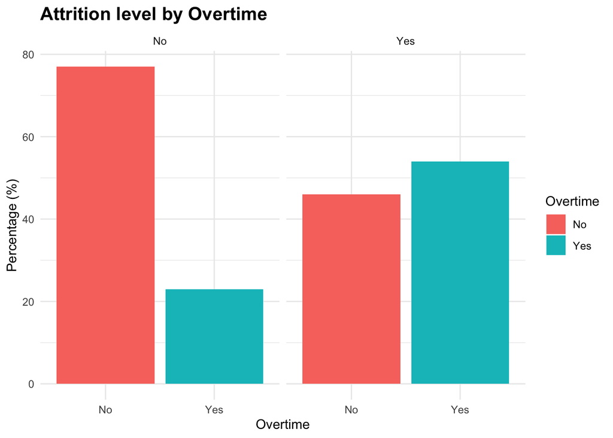

```r
data %>% count(attrition, over_time) %>% group_by(attrition) %>%
  mutate(pct=round(prop.table(n),2) * 100) %>%
  ggplot(aes(x=over_time, y=pct, fill=over_time)) +
  geom_bar(stat="identity") +
  facet_wrap(~attrition) +
  labs(title="Attrition level by Overtime", x="Overtime", y="Percentage (%)")+
  scale_fill_discrete(name = "Overtime")+
  theme(plot.title = element_text(size=15, face="bold"))
```

## How environment, job satisfaction and involvement affects the attrition?

We now look at how environment satisfaction, job involvement, job satisfaction, and years since last promotion impact employees attrition

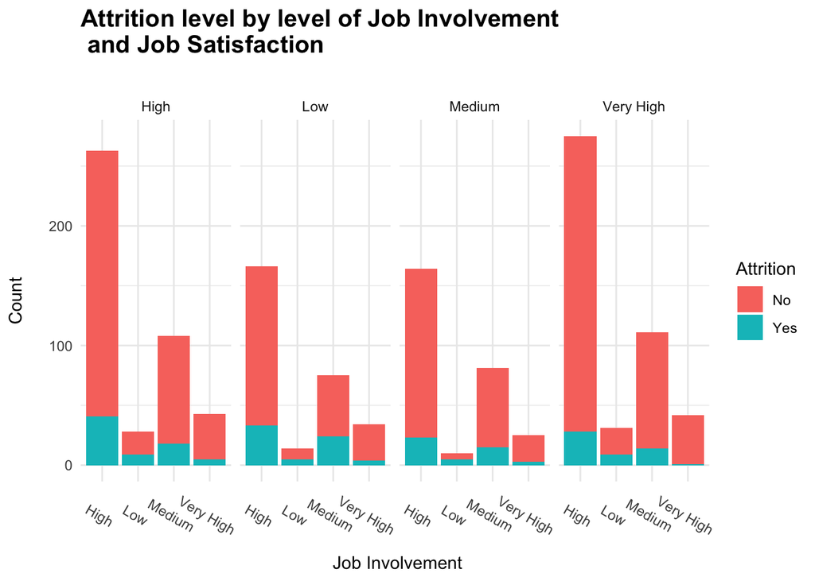

```r
data %>% mutate(job_involvement=case_when(job_involvement == 1 ~ 'Low',
                                          job_involvement == 2 ~ 'Medium',
                                          job_involvement == 3 ~ 'High',
                                          job_involvement == 4 ~ 'Very High'),
                job_satisfaction=case_when(job_satisfaction == 1 ~ 'Low',
                                          job_satisfaction == 2 ~ 'Medium',
                                          job_satisfaction == 3 ~ 'High',
                                          job_satisfaction == 4 ~ 'Very High')) %>%
  ggplot(aes(x  = job_involvement, fill=attrition)) +
  geom_bar() +
  facet_grid(~job_satisfaction)+
  labs(x="\n Job Involvement", y="Count\n",
        title = "Attrition level by level of Job Involvement \n and Job Satisfaction \n")+
  scale_fill_discrete(name = "Attrition")+
  theme(axis.text.x = element_text(angle=-30), plot.title = element_text(size=15, face="bold"))
```

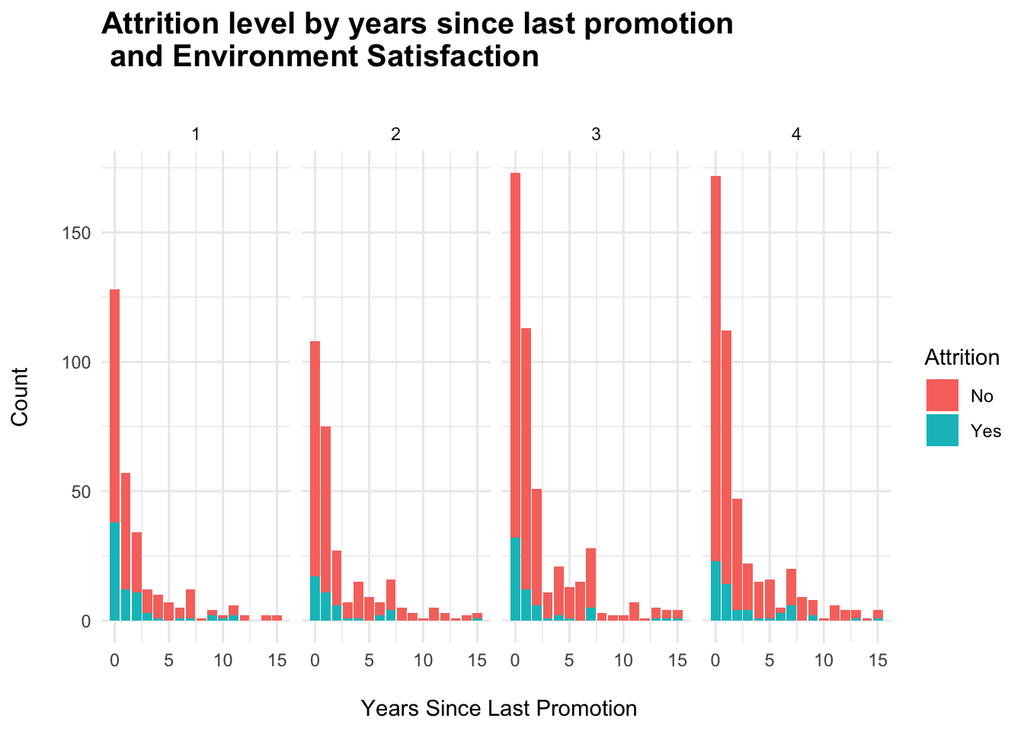

```r
data %>%
  ggplot(aes(x  = years_since_last_promotion, group = attrition, fill=attrition)) +
  geom_bar() +
  facet_grid(~environment_satisfaction)+
  labs(x="\n Years Since Last Promotion", y="Count\n",
        title = "Attrition level by years since last promotion \n and Environment Satisfaction \n")+
  scale_fill_discrete(name = "Attrition")+
  theme(plot.title = element_text(size=15, face="bold"))
```

Employees that have low environment satisfaction and within theirs 2 years since the last promotion has the highest attrition rate.

## What does the profile of the employees that burn out look like?

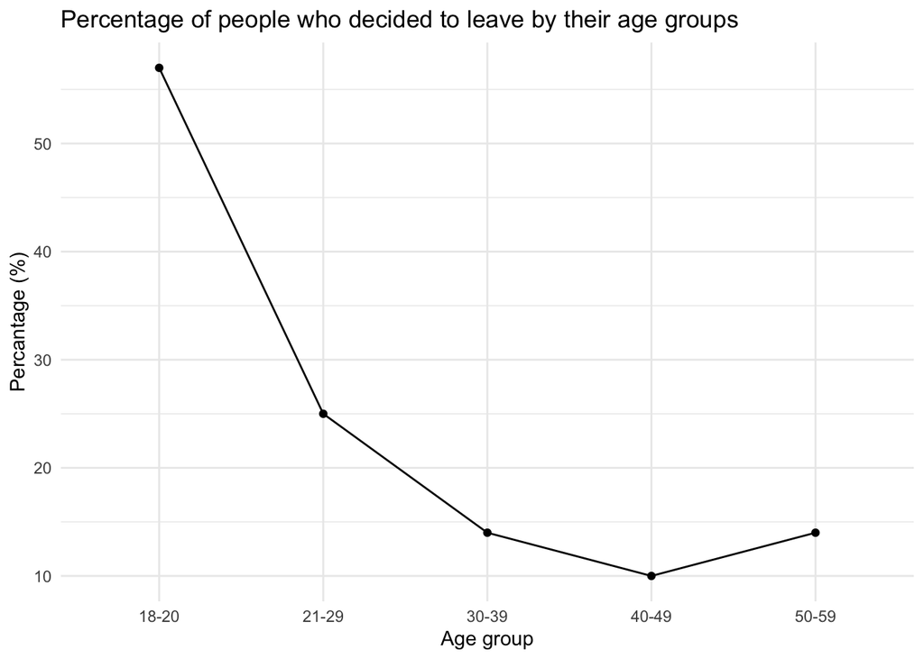

```r
data %>% mutate(age_group = case_when(18 <= age & age <= 20 ~ "18-20",
                                      21 <= age & age <= 29 ~ "21-29",
                                      30 <= age & age <= 39 ~ "30-39",
                                      40 <= age & age <= 49 ~ "40-49",
                                      50 <= age & age <= 59 ~ "50-59",
                                      60 <= age ~ "60 or older"
                                      )) %>%
  group_by(age_group, attrition) %>%
  count() %>%
  mutate(s = case_when(age_group == "18-20" ~ 28,
                       age_group == "21-29" ~ 298,
                       age_group == "30-39" ~ 622,
                       age_group == "40-49" ~ 349,
                       age_group == "50-59" ~ 168,
                       age_group == "60 or older" ~ 5
                                      )) %>%
  mutate(pct = round((n / s)*100)) %>%
  filter(attrition == "Yes") %>%
  ggplot(aes(age_group, pct)) +
  geom_point() +
  geom_line(group = 1) +
  labs(x = "Age group", title = "Percentage of people who decided to leave by their age groups", y = "Percantage (%)")
```

Looking at a data from IBM, a conclusion can be made that younger people tend to leave more often in comparison to other age groups. As age increases, the percentage of people who quit their job decreases drastically. Young employee, who is single and has a lower monthly income is more likely to quit in comparison to other groups. And employees before their 50s, who are not single and have higher salary are less likely to start looking for a job somewhere else or retire. There is an increase in percentage of positive attrition starting at age 50 that can be connected to the age of employee.

The profile of a worker which is the most like to churn:

1. Young
2. Low salary
3. Working overtime
4. Single
5. Working as a sales rep or a lab tech
6. Has a low overall satisfaction level
7. Travels frequently

Let’s move on to build our model

# Modelling

## Setting the dataset

Based on the findings of our exploratory analysis, we found that there are only certain variables that are significant for our model in predicting employees attrition. So we will prepare our working dataset:

```r
data_model <- data %>% select(attrition, monthly_income, over_time,
                              job_role, job_level, age,environment_satisfaction,
                              marital_status, relationship_satisfaction,
                              years_since_last_promotion, department, business_travel,
                              job_involvement, job_satisfaction,
                              work_life_balance, num_companies_worked, distance_from_home) %>%
                        mutate_if(is.character,factor)
```

## Preprocessing

We split our data into training and testing. Training set will be used for model learning and test will be used for fitting and making predictions. Before splitting the model, set.seed was added. As initial_split uses random splitting of the data, we have to makes sure that for the research purposes the split is the same every time we run the code. In this research the bootstrap method will also be used. Bootstrap is a resampling method, where the data set is divide into equal size samples and are repeatedly drawn.

```r
set.seed(2021)

split <- initial_split(data_model)

train <- training(split)

test <- testing(split)

folds <- bootstraps(train, strata = attrition)
```

Let’s build our models:

## Build Logistic regression model

Logistic regression is one of the ways to model a binomial outcome (yes or no outcomes). The model uses a regression analysis technique, but in comparison to linear technique, it is capable of predicting probability, because the prediction will always lie between 0 and 1, whereas in linear regression it exceeds those limits. Using the logistiv regression we will try to predict what employes might quit the company.

This process starts with specifying the recipe, which includes setting the model where outcome will be attrition and adding training data. Preprocessing steps include:

- `step_novel()` to create a specification of a recipe step that will assign a previously unseen factor level to a new value.
- `step_dummy()` to create dummy variables from all categorical variables.
- `step_zv()` to filter out all numeric variables that have zero variance.
- `step_normalize()` to normalize (center and scale) all numeric variables.

The next step would be specifying the model, mode, engine and parameters. As we don’t know the exact penalty and mixture parameters, we are using tune function. Penalty parameter controls the amount of regularization and mixture controls the proportion of lasso penalty. The mode is classification, as the predictor is a factor, not a number, and glmnet engine. For logistic regression there are two possible engines that can be used in this research scenario, glm and glmnet. Glmnet has advantages when there are many features and little observation. As our data set is fairly small, we will be using glmnet as an engine.

After that, the workflow is set. It puts together the recipe and model specifications. As a separate step we have to specify the models grid, so when the model is tuning, the sequence of parameters values are used in different models. In the next stage we will determine what parameters and which model turned out to be most accurate.

```r
glmnet_recipe <-
  recipe(formula = attrition ~ ., data = train) %>%
  step_novel(all_nominal(), -all_outcomes()) %>%
  step_dummy(all_nominal(), -all_outcomes()) %>%
  step_zv(all_predictors()) %>%
  step_normalize(all_predictors(), -all_nominal())

glmnet_spec <-
  logistic_reg(penalty = tune(), mixture = tune()) %>%
  set_mode("classification") %>%
  set_engine("glmnet")

glmnet_workflow <-
  workflow() %>%
  add_recipe(glmnet_recipe) %>%
  add_model(glmnet_spec)

glmnet_grid <- tidyr::crossing(penalty = 10^seq(-6, -1, length.out = 20), mixture = c(0.05,
    0.2, 0.4, 0.6, 0.8, 1))

glmnet_tune <-
  tune_grid(glmnet_workflow, resamples = folds, grid = glmnet_grid, metrics = metric_set(accuracy, roc_auc))
```

## Building random forest model

In this step we will build a random forest model. Random forest models work by collecting the predictions that were made by multiple decision trees. The first step would be creating a recipe for the mode, just like before attrition will be the outcome and we will be using train data set. The second step would be specifying the model mode and engines. As attrition is a categorical value, the model mode will be classification and engine used for this model will be “ranger”. When we set the model, some parameters like like mtry (“number of predictors that will be randomly sampled at each split when creating the tree models”) or min_n (“the minimum number of data points in a node that are required for the node to be split further”) can be adjusted to optimize their performance. For that we will use tune function. When model is finalized, best values for mtry and min_n will be reflected in the fitted model. Then, in the workflow we connect both recipe and model specification. The last step in this section would be tuning the model. For that, previously created workflow is used, data resamples are added and the number of grids is picked. In this scenario we picked 11 grids.

```r
ranger_recipe <-
  recipe(formula = attrition ~ ., data = train)

ranger_spec <-
  rand_forest(mtry = tune(), min_n = tune(), trees = 1000) %>%
  set_mode("classification") %>%
  set_engine("ranger")

ranger_workflow <-
  workflow() %>%
  add_recipe(ranger_recipe) %>%
  add_model(ranger_spec)

set.seed(1234)
doParallel::registerDoParallel()
ranger_tune <-
  tune_grid(ranger_workflow, resamples = folds, grid = 11, metrics = metric_set(accuracy, roc_auc))
```

## Evaluating the models

### Logical regression model

```r
show_best(glmnet_tune, metric = "accuracy")
# A tibble: 5 × 8
  penalty mixture .metric  .estimator  mean     n std_err .config
    <dbl>   <dbl> <chr>    <chr>      <dbl> <int>   <dbl> <chr>
1 0.0162     0.05 accuracy binary     0.873    25 0.00190 Preprocessor1_Model017
2 0.00264    0.05 accuracy binary     0.872    25 0.00215 Preprocessor1_Model014
3 0.00886    0.4  accuracy binary     0.872    25 0.00203 Preprocessor1_Model056
4 0.00886    0.2  accuracy binary     0.872    25 0.00202 Preprocessor1_Model036
5 0.00483    1    accuracy binary     0.872    25 0.00222 Preprocessor1_Model115

final_glmnet <- glmnet_workflow %>%
  finalize_workflow(select_best(glmnet_tune))
```

### Random forest model model

```r
show_best(ranger_tune, metric = "accuracy")
# A tibble: 5 × 8
   mtry min_n .metric  .estimator  mean     n std_err .config
  <int> <int> <chr>    <chr>      <dbl> <int>   <dbl> <chr>
1     4    12 accuracy binary     0.861    25 0.00258 Preprocessor1_Model09
2     2     6 accuracy binary     0.859    25 0.00238 Preprocessor1_Model04
3     8    17 accuracy binary     0.858    25 0.00235 Preprocessor1_Model11
4     6    36 accuracy binary     0.858    25 0.00243 Preprocessor1_Model08
5     7    32 accuracy binary     0.858    25 0.00239 Preprocessor1_Model03

final_rf <- ranger_workflow %>%
  finalize_workflow(select_best(ranger_tune))
```

## Fitting the models

### Logical regression model

```r
fit <- last_fit(final_glmnet, split)

collect_metrics(fit)
# A tibble: 2 × 4
  .metric  .estimator .estimate .config
  <chr>    <chr>          <dbl> <chr>
1 accuracy binary         0.864 Preprocessor1_Model1
2 roc_auc  binary         0.855 Preprocessor1_Model1

collect_predictions(fit) %>%
  conf_mat(truth = attrition, estimate = .pred_class)
          Truth
Prediction  No Yes
       No  300  48
       Yes   2  18
```

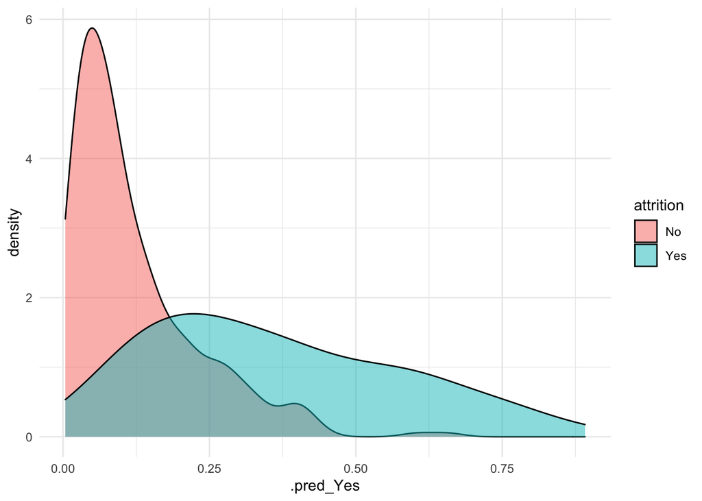

```r
collect_predictions(fit) %>%
  ggplot() +
  geom_density(aes(x = .pred_Yes, fill = attrition),
               alpha = 0.5)
```

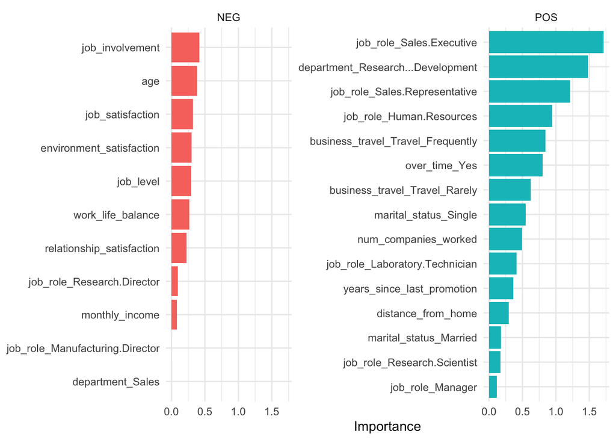

```r
best_auc <- glmnet_tune %>%
  select_best("roc_auc")

final_lasso <- finalize_workflow(glmnet_workflow, best_auc)

final_lasso %>%
  fit(train) %>%
  pull_workflow_fit() %>%
  vi(lambda = best_auc$penalty) %>%
  group_by(Sign) %>%
  top_n(20, wt = abs(Importance)) %>%
  ungroup() %>%
  mutate(
    Importance = abs(Importance),
    Variable = str_remove(Variable, "tfidf_text_"),
    Variable = fct_reorder(Variable, Importance)
  ) %>%
  ggplot(aes(x = Importance, y = Variable, fill = Sign)) +
  geom_col(show.legend = FALSE) +
  facet_wrap(~Sign, scales = "free_y") +
  labs(y = NULL)
```

### Random forest model

In this step we are applying the workflow with the final version of model parameters to an actual data set. As a result, a confusion matrix is set, where we can see the exact number of wrong and right predictions.

```r
  # fit on the training set and evaluate on test set
rf_fit <- last_fit(final_rf, split)

collect_metrics(rf_fit)
# A tibble: 2 × 4
  .metric  .estimator .estimate .config
  <chr>    <chr>          <dbl> <chr>
1 accuracy binary         0.848 Preprocessor1_Model1
2 roc_auc  binary         0.843 Preprocessor1_Model1

collect_predictions(rf_fit) %>%
  conf_mat(truth = attrition, estimate = .pred_class)
          Truth
Prediction  No Yes
       No  299  53
       Yes   3  13
```

Plot distributions of the predicted probability for each class.

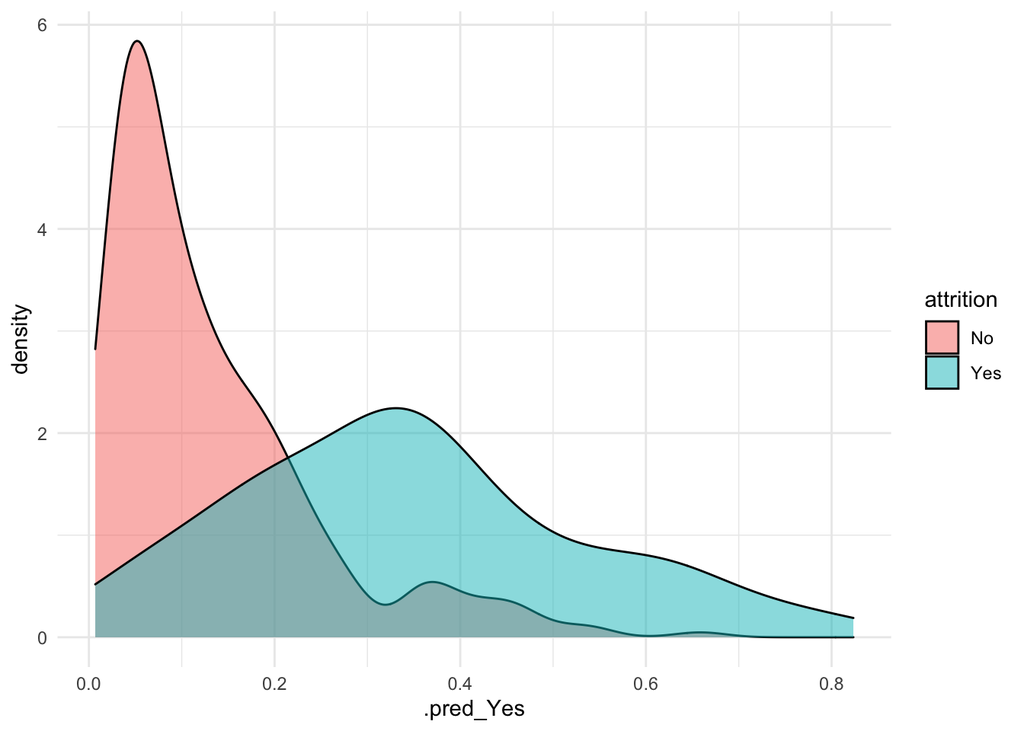

```r
collect_predictions(rf_fit) %>%
  ggplot() +
  geom_density(aes(x = .pred_Yes, fill = attrition),
               alpha = 0.5)
```

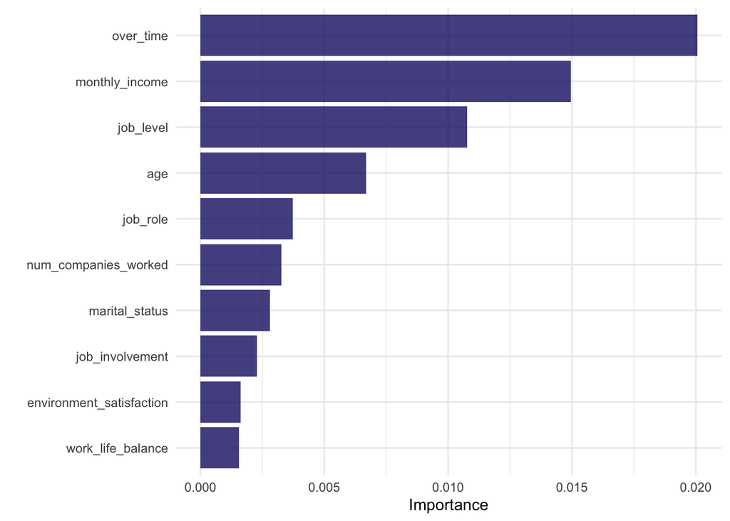

```r
imp_spec <- ranger_spec %>%
  finalize_model(select_best(ranger_tune)) %>%
  set_engine("ranger", importance = "permutation")

workflow() %>%
  add_recipe(ranger_recipe) %>%
  add_model(imp_spec) %>%
  fit(train) %>%
  pull_workflow_fit() %>%
  vip(aesthetics = list(alpha = 0.8, fill = "midnightblue"))
```

### Comparison

Let’s also do an unsupervised model

## Clustering model - K Means

Aim to answer our sub question 4: Clustering the employees based on attrition. What kind of employees burn out?

For clustering, separate data frame was created that only includes numeric variables and only people who decided to quit their job. By doing that, we can determine patterns among those who decided not to stay at the IBM. For us to build this model we need data frame that consists of numeric variables and a number of clusters that will be set. To find the most suitable and efficient number of cluster several methods can be used.

Now we are building the model using kmeans function, specifying the number of clusters and how many random sets should be chosen in n start.

```r
data_yes <- data_attrition_yes %>%
  select(monthly_income, job_level, age, years_since_last_promotion, distance_from_home)

k3 <- kmeans(data_yes, centers = 3, nstart = 10)
k3
K-means clustering with 3 clusters of sizes 10, 54, 173

Cluster means:
  monthly_income job_level      age years_since_last_promotion
1      16451.200  4.400000 46.80000                   7.300000
2       8437.222  2.592593 38.57407                   3.185185
3       2973.520  1.179191 31.29480                   1.248555
  distance_from_home
1            9.30000
2           12.75926
3           10.04624

Clustering vector:
  [1] 2 3 3 3 3 3 3 3 3 3 1 3 3 3 2 3 3 2 2 3 2 2 3 3 2 3 3 3 3 2 2 2 2 3 2 3 3
 [38] 3 3 3 2 3 3 2 3 3 2 3 3 3 3 3 3 3 2 2 3 3 3 3 3 3 3 3 3 1 3 2 2 3 3 3 3 3
 [75] 3 3 3 3 3 3 3 3 2 3 3 3 2 1 3 3 3 3 1 3 2 3 3 3 3 3 3 3 3 3 3 3 3 3 3 2 2
[112] 3 1 3 3 3 3 3 3 3 3 1 3 3 3 3 3 3 2 2 2 3 3 3 3 3 3 2 3 2 3 2 1 3 3 3 3 3
[149] 3 3 3 1 3 2 3 3 3 2 2 3 3 2 1 3 3 2 3 3 2 3 3 3 2 3 2 3 3 3 2 3 3 3 3 3 3
[186] 2 3 2 3 3 3 2 3 3 3 3 3 3 3 3 1 2 2 3 3 2 2 3 3 3 3 2 3 3 3 2 3 3 2 3 2 3
[223] 3 3 3 3 2 3 3 3 3 2 3 3 3 2 2

Within cluster sum of squares by cluster:
[1]  92033430 179229826 207055569
 (between_SS / total_SS =  84.7 %)

Available components:

[1] "cluster"      "centers"      "totss"        "withinss"     "tot.withinss"
[6] "betweenss"    "size"         "iter"         "ifault"
```

```r
data_attrition_no %>%
  mutate(job_level = case_when(job_level == 1 ~ 1, job_level == 2 ~ 3, job_level == 3 ~ 3, job_level == 4 ~ 4, job_level == 5 ~ 4)) %>%
  group_by(job_level) %>%
  summarise(m = mean(monthly_income),
            d = mean(distance_from_home),
            p = mean(years_since_last_promotion),
            a = mean(age))
# A tibble: 3 × 5
  job_level      m     d     p     a
      <dbl>  <dbl> <dbl> <dbl> <dbl>
1         1  2854.  8.33  1.21  33.4
2         3  6704.  9.31  2.27  37.6
3         4 16997.  8.76  4.56  47.6
```

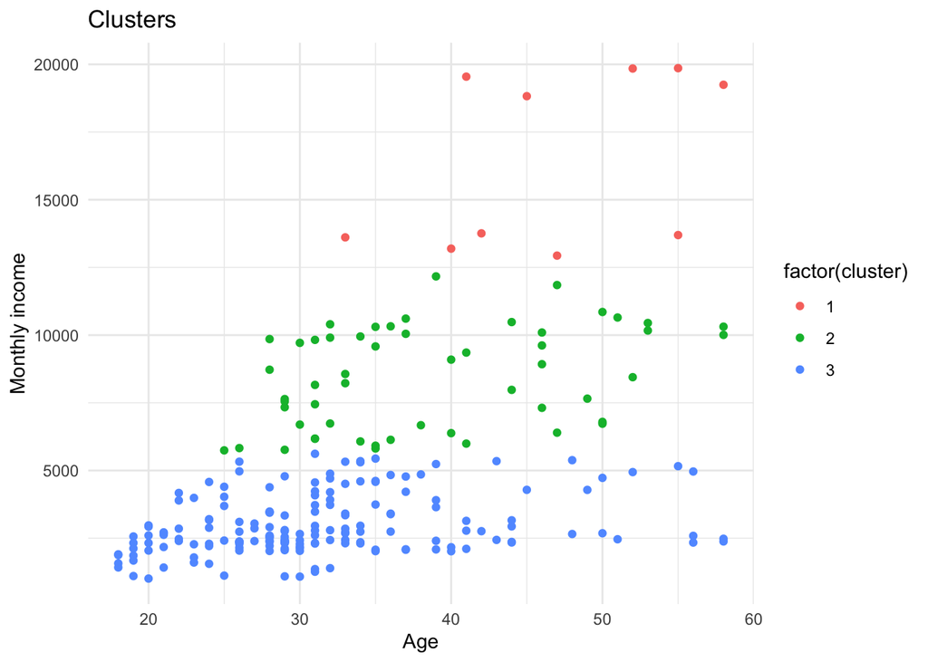

```r
data_yes %>%
  as_tibble() %>%
  mutate(cluster = k3$cluster) %>%
  ggplot(aes(age, monthly_income, color = factor(cluster))) +
  geom_point() +
  labs(y = "Monthly income", x = "Age", legend = "Cluster", title = "Clusters")
```

In conclusion, k-means is a very fast and easy algorithm to use for clustering. However, there are some downsides to using it. First of all it requires to specify the number of clusters. And different methods of choosing the amount of clusters might show different results. Second disadvantage of the k-means is that it is very sensitive to outlines. And third one is that the result can change if we change the order of the data (Kassambara 2017).

## References

- Kapphahn, K 2017, ‘Why Employee Turnover Rate Is High for Young Workers’, ADP, viewed 9 September 2021, https://www.adp.com/spark/articles/2017/01/why-employee-turnover-rate-is-high-for-young-workers.aspx.
- Kassambara, A 2017, Practical Guide to Cluster Analysis in R: Unsupervised Machine Learning (Multivariate Analysis), vol. 1, no. 1, viewed 10 September 2021, https://www.amazon.com/Practical-Guide-Cluster-Analysis-Unsupervised/dp/1542462703/ref=sr_1_1?ie=UTF8&qid=1493169647&sr=8-1&keywords=practical+guide+to+cluster+analysis.